# Visualising Police Data

# First Map: Concentration of Stop and Search’s in London

[figure not shown]

```r
ggplot(data = london_wgs84, aes(fill = per_sq_km)) +
   geom_sf() +
   scale_fill_gradient(low = "#e5f5f9", high = "#e41a1c") + theme(panel.grid.major = element_line(linetype = "blank"),
    panel.background = element_rect(fill = "gray100",
        size = 0.1))+
  ylab("")+
  xlab("")+
  labs(title = "Differences in S&S for each Ward in London",
       subtitle = "S&S Rates per Square Km between Oct 2019 to Oct 2022")+
  guides(fill=guide_legend(title="Number of S&S")) + theme(plot.subtitle = element_text(family = "serif"),
    plot.title = element_text(family = "serif",
        size = 15, face = "bold"), legend.title = element_text(size = 10,
        family = "serif"))+
  geom_curve(xend = -0.14,
             yend = 51.515,
             x = 0.21,
             y = 51.67,
             curvature = 0.1,
             arrow = arrow(length = unit(0.2, "cm")))+
  geom_label(aes(x=0.22, y=51.68, label = "West End: Most S&S/km2 at 1264"),
             size = 2.2,
             position=position_dodge(width = 0.5))+
  labs(caption = "Source: https://data.police.uk")
```

## Correcting for missing values in June 2022

```r
st1 <- stop_search_offence%>%
  filter(month_year != "2019-Sep") %>%
  group_by(month_year)%>%
  count(officer_defined_ethnicity) %>%
  mutate(month_year = as.Date(parse_date_time(month_year, "ym")))

average_for_june <- stop_search_offence %>%
  filter(month_year == c("2022-May","2022-Jul")) %>%
  group_by(officer_defined_ethnicity) %>%
  count(officer_defined_ethnicity) %>%
  mutate(n = as.integer(n))
st1[129, 3] = average_for_june$n[1]
st1[130, 3] = average_for_june$n[2]
st1[131, 3] = average_for_june$n[4]
```

# Second Graph: Stop and Search for each Ethnicity

The first two chunks of code create two very basic dataframes (one for White and one for the other ethnicity because the white text needs to be above the curve) that contain the Sept 2022 as a date, each ethnicity and a value of n corresponding to the actual value of n at that time. We then use these dataframes in geom_text to add the ethnicity next to each line. This greatly improves readability.

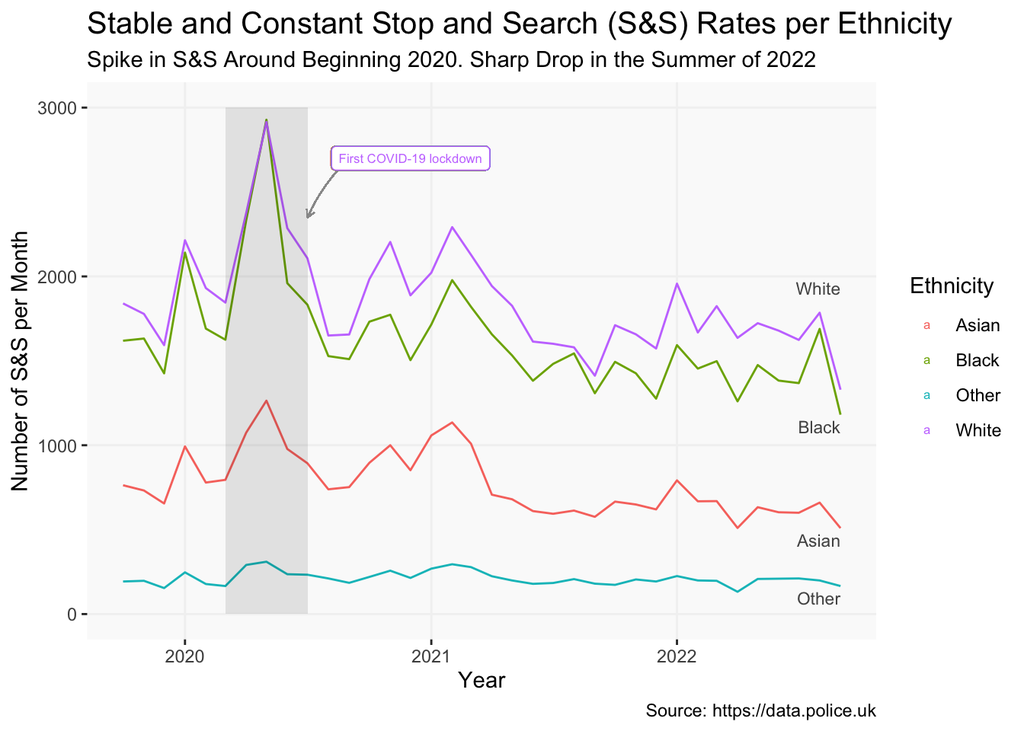

```r
month_year <- c("2022-09-01", "2022-09-01", "2022-09-01")
officer_defined_ethnicity <- c("Black", "Asian", "Other")
n <- c("1181", "509", "166")
df <- data.frame(month_year, officer_defined_ethnicity, n)

month_year_white <- c("2022-09-01")
officer_defined_ethnicity_white <- c("White")
n_white <- c("1329")
dfwhite <- data.frame(month_year, officer_defined_ethnicity, n)

st1 %>%
  ggplot(aes(x=month_year, y = n, color = officer_defined_ethnicity))+
  geom_line() +
  annotate("rect",
    xmin = as.Date("2020-03-01", "%Y-%m-%d"),
    xmax = as.Date("2020-07-01", "%Y-%m-%d"),
    ymin = 0,
    ymax = 3000,
    alpha = 0.1,
    fill = "black") +

  theme(panel.grid.major = element_line(colour = "gray95"),
    panel.grid.minor = element_line(linetype = "blank"),
    plot.title = element_text(size = 15),
    panel.background = element_rect(fill = "gray98",
        size = 1.4)) +
  labs(title = "Stable and Constant Stop and Search (S&S) Rates per Ethnicity",
    x = "Year", y = "Number of S&S per Month",
    colour = "Ethnicity", subtitle = "Spike in S&S Around Beginning 2020. Sharp Drop in the Summer of 2022",
    caption = "Source: https://data.police.uk")+

  geom_curve(xend = as.Date("2020-07-01", "%Y-%m-%d"),
             yend = 2350,
             x = as.Date("2020-09-01", "%Y-%m-%d"),
             y = 2700,
             curvature = 0.1,
             color = "#999999",
             size = 0.3,
             arrow = arrow(length = unit(0.15, "cm")))+
    geom_label(aes(x=as.Date("2020-12-01", "%Y-%m-%d"),
                   y=2700,
                   label = "First COVID-19 lockdown"), size = 2.2,
               position=position_dodge(width = 0.9))+
  geom_text(data = df,
    aes(label = officer_defined_ethnicity, x = as.Date("2022-09-01", "%Y-%m-%d"), y = as.numeric(n) -70),
    color = "#525252",check_overlap = TRUE,
    size = 3,
    hjust = 1
  )+
  geom_text(data = dfwhite,
    aes(label = officer_defined_ethnicity_white, x = as.Date("2022-09-01", "%Y-%m-%d"), y = as.numeric(n_white) +600),
    color = "#525252",check_overlap = TRUE,
    size = 3,
    hjust = 1
  )
```

# Third graph: Fireworks Rule on Nov 5th

For the last graph we look at an interesting occurance, mainly the spike in firework searches around Nov 5th, Gay Fawkes Night.

```r
library(zoo)
```

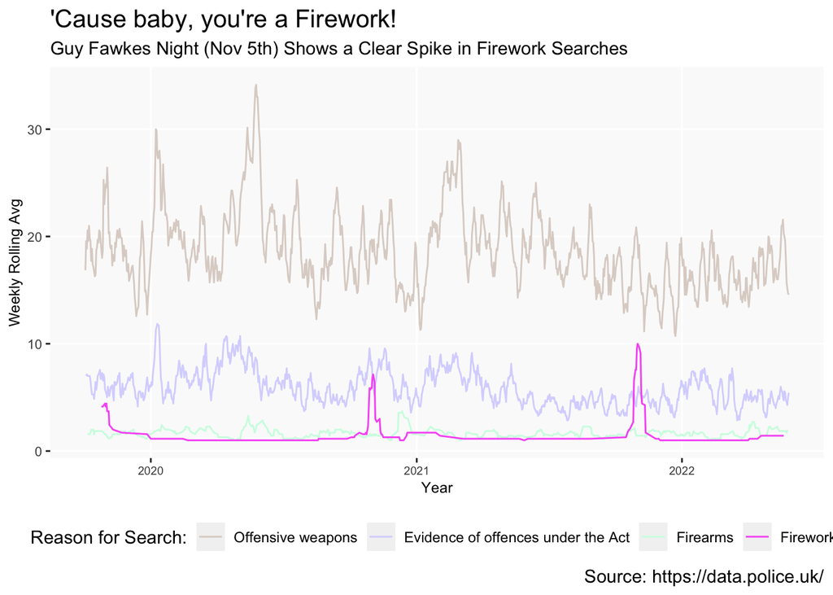

```r
which_objects_of_search = c("Evidence of offences under the Act", "Offensive weapons", "Firearms", "Fireworks")
my_colours = c("#ddd3cc", "#d9d6fe", "#cffce3", "#f763f5")


st3 <- stop_search_offence %>%
  filter(object_of_search %in% which_objects_of_search) %>%
  mutate(date = format(as.POSIXct(date,
                           format = '%Y/%m/%d %H:%M:%S'),
                format = '%Y/%m/%d'),
         date = as.Date(date)) %>%
  filter(date < "2022-06-01") %>%
  group_by(date, object_of_search) %>%
  count(object_of_search)%>%
  ungroup(date) %>%
  mutate(rolling_avg = rollmean(n, k = 7, fill = NA, align = "center"),
          fireworks = ifelse(object_of_search == "Fireworks", TRUE, FALSE)) %>%
  drop_na()

ggplot(st3, aes(x=date, y = rolling_avg, group = object_of_search, color =object_of_search))+
   geom_line() +
  scale_color_manual(values = my_colours) + theme(plot.subtitle = element_text(size = 11),
    plot.caption = element_text(size = 11),
    plot.title = element_text(size = 15)) +labs(title = "'Cause baby, you're a Firework!",
    subtitle = "Guy Fawkes Night (Nov 5th) Shows a Clear Spike in Firework Searches",
    caption = "Source: https://data.police.uk/") + theme(legend.position = "top", legend.direction = "horizontal") + theme(panel.grid.minor = element_line(linetype = "blank"),
    panel.background = element_rect(fill = "gray98"),
    legend.position = "bottom")+
  xlab("Year")+
  ylab("Weekly Rolling Avg")+
  labs(color = "Reason for Search:") + theme(axis.title = element_text(size = 9),
    axis.text = element_text(size = 8), axis.text.x = element_text(size = 7))
```